# Domain:-Finance

# Analyse the data and give the answers of below questions:

```python
import pandas as pd
```

```python
df=pd.read_csv('C:/Users/Sudu/Desktop/ETlhive/Python/Python_projects/Loan_data_analysis_project/Loan_dataset.csv')
```

```python
df.columns
```

```
Index(['Loan ID', 'Customer ID', 'Loan Status', 'Current Loan Amount', 'Term',
       'Credit Score', 'Annual Income', 'Years in current job',
       'Home Ownership', 'Purpose', 'Monthly Debt', 'Years of Credit History',
       'Months since last delinquent', 'Number of Open Accounts',
       'Number of Credit Problems', 'Current Credit Balance',
       'Maximum Open Credit', 'Bankruptcies', 'Tax Liens'],
      dtype='object')
```

# 1.What is the average current loan amount for each loan status?

```python
df.groupby('Loan Status')['Current Loan Amount'].mean().reset_index()
```

|  | Loan Status | Current Loan Amount |
| --- | --- | --- |
| 0 | Charged Off | 3.249752e+05 |
| 1 | Fully Paid | 1.510694e+07 |

# 2.How does the credit score vary with the annual income?

```python
df[['Credit Score', 'Annual Income']].corr()
```

|  | Credit Score | Annual Income |
| --- | --- | --- |
| Credit Score | 1.000000 | -0.017078 |
| Annual Income | -0.017078 | 1.000000 |

# 3.Is there a correlation between the number of open accounts and the current credit balance?

```python
df[['Number of Open Accounts', 'Current Credit Balance']].corr()
```

|  | Number of Open Accounts | Current Credit Balance |
| --- | --- | --- |
| Number of Open Accounts | 1.000000 | 0.228136 |
| Current Credit Balance | 0.228136 | 1.000000 |

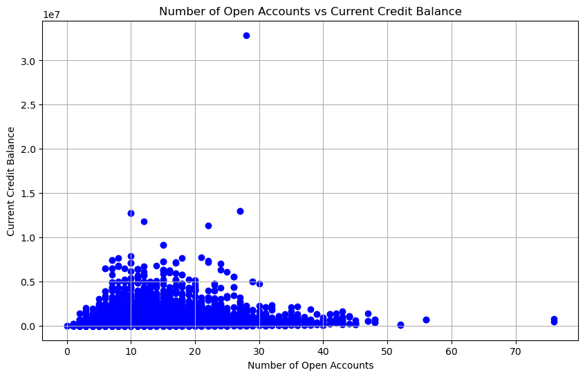

```python
import pandas as pd
import matplotlib.pyplot as plt

plt.figure(figsize=(10, 6))
plt.scatter(df['Number of Open Accounts'], df['Current Credit Balance'], color='blue')
plt.title('Number of Open Accounts vs Current Credit Balance')
plt.xlabel('Number of Open Accounts')
plt.ylabel('Current Credit Balance')
plt.grid(True)
plt.show()
```

# 4.What is the distribution of credit scores across different home ownership types?

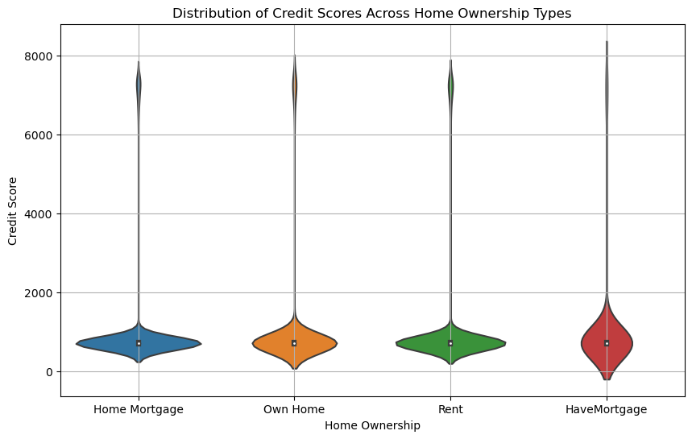

```python
import pandas as pd
import seaborn as sns

plt.figure(figsize=(10, 6))
sns.violinplot(x='Home Ownership', y='Credit Score', data=df)
plt.title('Distribution of Credit Scores Across Home Ownership Types')
plt.xlabel('Home Ownership')
plt.ylabel('Credit Score')
plt.grid(True)
plt.show()
```

# 5.How does the annual income differ for different purposes of loans?

```python
df.groupby('Purpose')['Annual Income'].agg(['mean', 'median', 'std']).reset_index()
```

|  | Purpose | mean | median | std |
| --- | --- | --- | --- | --- |
| 0 | Business Loan | 1.591963e+06 | 1342103.0 | 1.047181e+06 |
| 1 | Buy House | 1.495251e+06 | 1183073.0 | 1.086381e+06 |
| 2 | Buy a Car | 1.220353e+06 | 1045636.5 | 7.442786e+05 |
| 3 | Debt Consolidation | 1.362464e+06 | 1170210.0 | 1.079726e+06 |
| 4 | Educational Expenses | 1.071051e+06 | 914574.5 | 8.076369e+05 |
| 5 | Home Improvements | 1.667437e+06 | 1384558.5 | 1.194598e+06 |
| 6 | Medical Bills | 1.409286e+06 | 1191072.0 | 9.529750e+05 |
| 7 | Other | 1.348516e+06 | 1121817.0 | 1.044702e+06 |
| 8 | Take a Trip | 1.219899e+06 | 1055003.5 | 7.642818e+05 |
| 9 | major_purchase | 1.430753e+06 | 1114065.0 | 1.488982e+06 |
| 10 | moving | 1.591375e+06 | 1104071.0 | 1.855030e+06 |
| 11 | other | 1.286008e+06 | 1074659.0 | 1.026819e+06 |
| 12 | renewable_energy | 1.473740e+06 | 1516466.0 | 6.796896e+05 |
| 13 | small_business | 1.547456e+06 | 1332812.0 | 1.045103e+06 |
| 14 | vacation | 1.155290e+06 | 874760.0 | 8.020623e+05 |
| 15 | wedding | 1.464233e+06 | 1206272.0 | 9.886829e+05 |

# 6.What is the average monthly debt for each term (short-term vs. long-term)?

```python
df.groupby('Term')['Monthly Debt'].mean().reset_index()
```

|  | Term | Monthly Debt |
| --- | --- | --- |
| 0 | Long Term | 21585.664968 |
| 1 | Short Term | 17274.158442 |

# 7.Is there a correlation between years of credit history and the current credit balance?

```python
df[['Years of Credit History', 'Current Credit Balance']].corr()
```

|  | Years of Credit History | Current Credit Balance |
| --- | --- | --- |
| Years of Credit History | 1.00000 | 0.20847 |
| Current Credit Balance | 0.20847 | 1.00000 |

# 8.How does the credit score vary with the years in the current job?

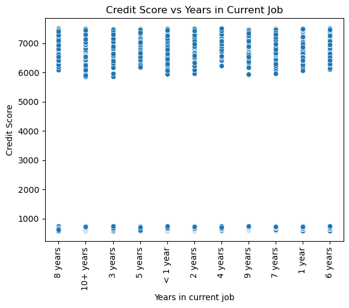

```python
import matplotlib.pyplot as plt
import seaborn  as sns
sns.scatterplot(data=df, x='Years in current job', y='Credit Score')
plt.title('Credit Score vs Years in Current Job')
plt.xticks(rotation=90)
plt.show()
```

# 9.What is the relationship between the number of credit problems and the number of open accounts?

```python
df[['Number of Credit Problems', 'Number of Open Accounts']].corr()
```

|  | Number of Credit Problems | Number of Open Accounts |
| --- | --- | --- |
| Number of Credit Problems | 1.000000 | -0.013995 |
| Number of Open Accounts | -0.013995 | 1.000000 |

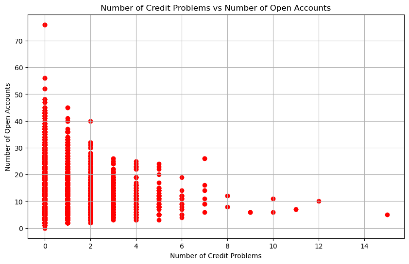

```python
import matplotlib.pyplot as plt

plt.figure(figsize=(10, 6))
plt.scatter(x='Number of Credit Problems', y='Number of Open Accounts', data=df,color='r')
plt.title('Number of Credit Problems vs Number of Open Accounts')
plt.xlabel('Number of Credit Problems')
plt.ylabel('Number of Open Accounts')
plt.grid(True)
```